# An exploration of popular post tones on Reddit

My data collection was focused on popular posts from Reddit.com, specifically regarding the (subjective) tone of their content and if there were any relationships between that and:

- The day they were posted.
- The comment/upvote relationship.
- The subject of the post.

## Are the top 10 posts more negative or positive based on the day?

First, we’ll look at the top 10 posts at the time of submission and see if there are any obvious difference in the count of each tone based on the day of submission. Obviously there are some issues regarding the subjectivity of the responses, but this could be seen as a typical user’s reaction to them.

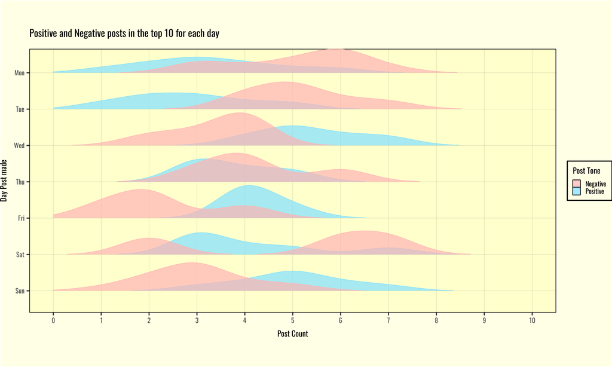

Overlapping density plots for counts of negative and positive posts for each day

If the day of posting was inconsequential to the post count for each tone we would expect these distributions to be extremely similar for each day, however we see that there’s some differences between them.

Specifically, we see that there appears to be a higher count of negative posts on Monday and Tuesday, which could possibly be explained by the fact that it’s the start of a standard work week. This would be expected to generally bring the mood down for those browsing the site, and could also mean that negative policy decisions that are finalised during the weekend are saved until Monday for release.

Distributions for the rest of the week seem roughly similar, and any differences could be explained by chance alone - however there’s an interesting bimodal distribution for negative posts on Saturday. This could be because there’s either some headline that’s dominating the headlines or everyone’s enjoying their weekend, and this dichotomy causes the split.

## Does the comment and upvote count relationship depend on the tone of the post?

Next, we’ll look at the comment and upvote count for the most popular post at the time of submission, and see if there’s any correlation between these variables and the tone of the post.

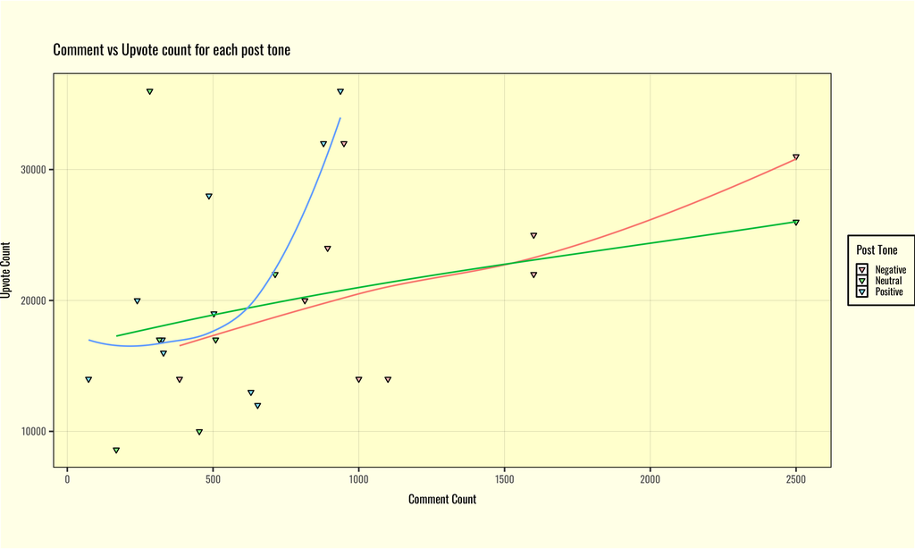

Comment and Upvote count relationship for each post tone

As expected, regardless of the tone of the post, the count of comment and upvotes is positively related. Interestingly however, it seems that people are happy to upvote positively themed post without commenting more often, and possibly comment more on negative posts.

This would be in line with common theories regarding engagement of content online, where negative content drives the most.

## Do the most popular post subjects have different tone breakdowns?

Finally, we’ll look at the top 5 most common post subjects, along with their corresponding tones.

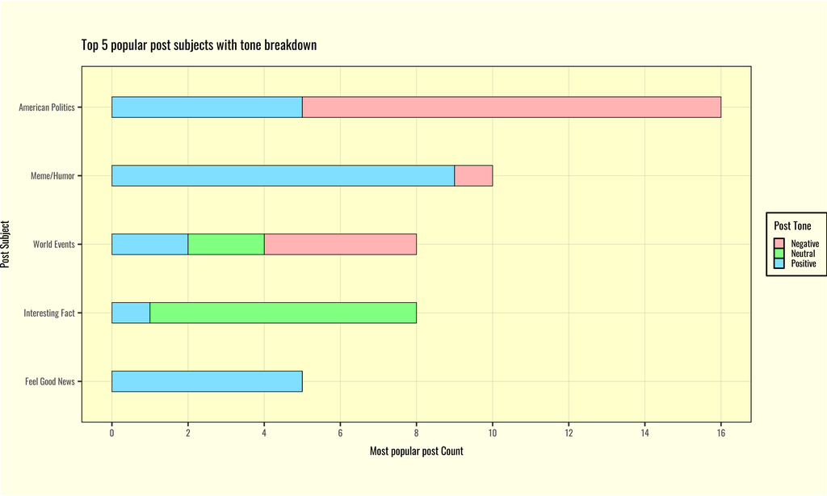

Top 5 most popular post subjects with tone breakdown

Unsurprisingly for an American website, we see American Politics at the top, with the majority of the corresponding posts being negative. This is also not surprising considering the left-leaning political alignment of the user base and data being collected soon after Trump came into office.

We also see that submissions we’d expect to be generally positive (Meme/Humor and Feel Good News) follow that assumption, along with World Events having a decent spread of tones. Interesting facts are generally neutral, which in itself is quite interesting.